# Visualizing Twitter Dog Rate Account

Every market known the importance of analyzing and gathering data.Looking into the data not only shows us what was working, but it gives us more insights to be successful on our next campaign .For this project we analyze twitter data particulary weRateDogs account in this when we did this analysis of this account we found the most kind of dogs that most people acquire and this means that this type of dog is close to humans and nice to them.

## Dog stage VS Number of tweet

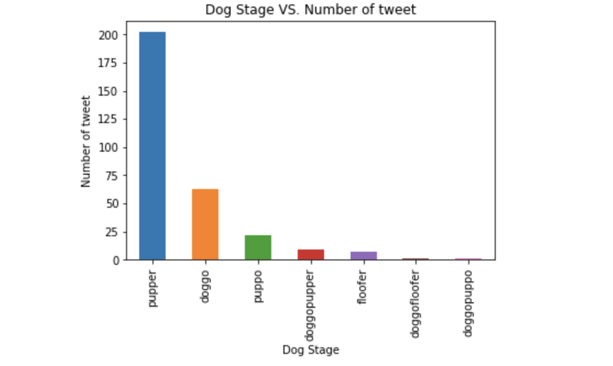

As we can see above the dog stage which is the most tweet containe is of pupper stage and there is too much diffrent beween the number of tweet between these stages.

## Dog stage VS Retweet

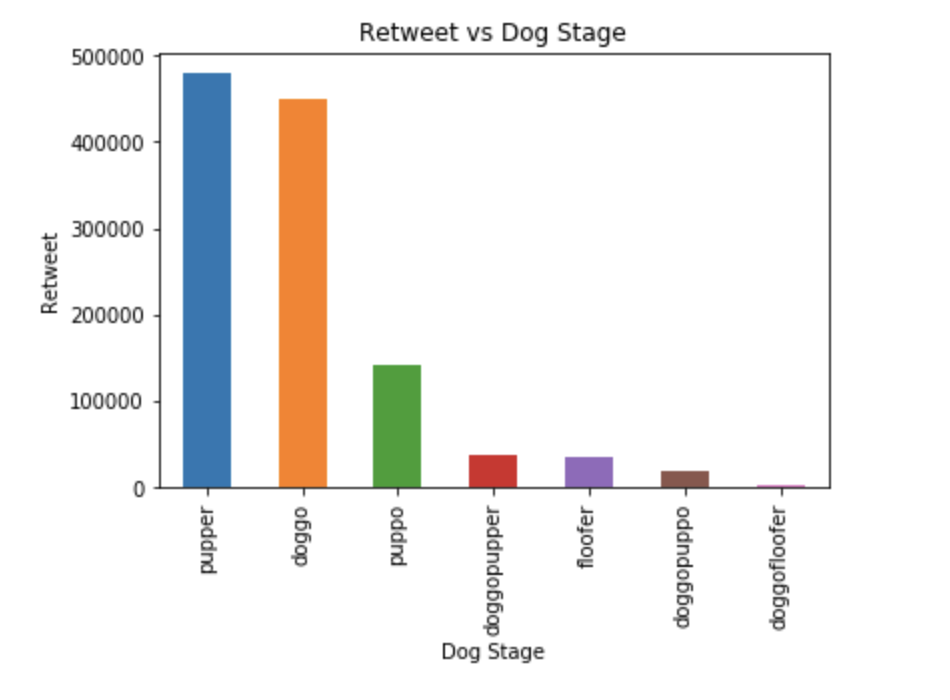

As we can see in above visualization the dog stage which is the have retweet count It is of pupper stage and then doggo stage there is not too much diffrent beween these two stages.

## Dog stage VS Favorite

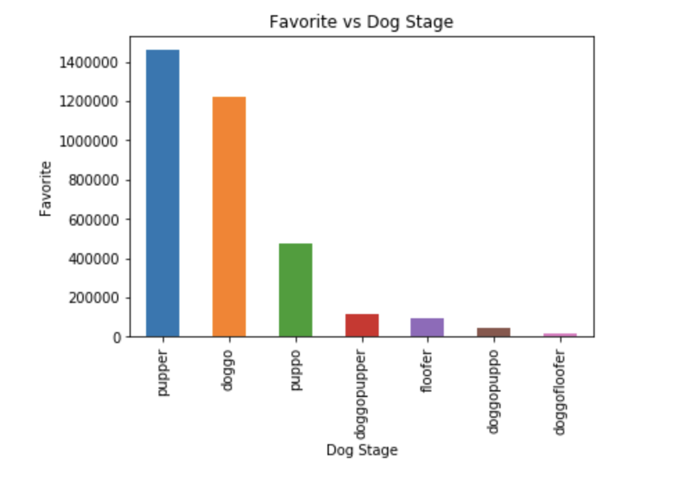

As we can see in above visualization the dog stage which is the have favorite count It is of pupper stage and then doggo stage also there is not too much diffrent beween these two stages.